# Examen Parcial - PARTE N°3

Grupo N° 6 - GeoCódigo

FECHA: 05-08-2021

## PARTE 3 - Se puede usar librerías

```r
library(tidyverse)
library(dplyr)
library(ggplot2)
```

**1. Se tiene el conjunto de datos de temperatura diaria (período 1928 - 2015) de ciertas estaciones metereológicas (temperatureDataset.csv), donde cada una de estas están asociadas a un código único (p.e.qc00000208).Si existen valores iguales a -99.9, considerarlos como missing values y convertirlos a NA.**

*Trabajaremos con la estación con código qc00000746*

```r
(data <-
  read_csv("data/temperatureDataset.csv") %>%
  select(DATE, all_of("qc00000746")) %>%
  mutate(DATE = as.Date(DATE, format = "%d/%m/%Y")) %>%
  rename(tmp = all_of("qc00000746")) %>%
  mutate(tmp = ifelse(tmp == -99.9, NA, tmp)) %>%
  arrange(DATE))
```

```
## # A tibble: 31,775 x 2
##    DATE         tmp
##    <date>     <dbl>
##  1 1928-11-02    NA
##  2 1928-11-03    NA
##  3 1928-11-04    NA
##  4 1928-11-05    NA
##  5 1928-11-06    NA
##  6 1928-11-07    NA
##  7 1928-11-08    NA
##  8 1928-11-09    NA
##  9 1928-11-10    NA
## 10 1928-11-11    NA
## # ... with 31,765 more rows
```

```r
tail(data) #Podemos conocer la fecha final
```

```
## # A tibble: 6 x 2
##   DATE         tmp
##   <date>     <dbl>
## 1 2015-10-26    NA
## 2 2015-10-27    NA
## 3 2015-10-28    NA
## 4 2015-10-29    NA
## 5 2015-10-30    NA
## 6 2015-10-31    NA
```

*Mediante una secuencia diaria comprobamos si la cantidad de elementos en el dataframe estan completos*

```r
seq(as.Date("1928-11-02"), as.Date("2015-10-31"), by = "day") %>%
  length()
```

```
## [1] 31775
```

NOTA: Los datos coinciden con la cantidad del dataframe. ¡¡¡ EXCELENTE !!!

**(a) Determine la cantidad de missing values para los años hidrológicos Sep 1983- Agost 1984 y Sep 1997- Agost 1998.**

*Creamos una función con dos argumentos a y b que representan los años hidrológicos*

```r
cantidad_na <- function(a, b) {
  a <- as.character(a)
  b <- as.character(b)

  data %>%
    filter(DATE >= a & DATE < b) %>%
    mutate(cantidad_NA = sum(is.na(tmp))) %>%
    summarise(cantidad_NA = unique(cantidad_NA))
}
cantidad_na("1983-09-01", "1984-08-31")
```

```
## # A tibble: 1 x 1
##   cantidad_NA
##         <int>
## 1           1
```

```r
cantidad_na("1997-09-01", "1998-08-31")
```

```
## # A tibble: 1 x 1
##   cantidad_NA
##         <int>
## 1           2
```

**(b) Calcule la serie de tiempo temperatura mensual ( si el de días con missing values, en un mes , supera el 5%, la temperatura mensual será considerado como un NA). Además, identifique, visualmente posibles valores atípicos y describa una posible causa.**

```r
(temp_mensual <-
  data %>%
  group_by(DATE = str_sub(DATE, 1, 7)) %>%
  mutate(
    valores_NA = sum(is.na(tmp)) * 100 / n()) %>%
  summarise(tmp = mean(tmp, na.rm = T),valores_NA = unique(valores_NA)) %>%# Tabla resumen
  mutate(tmp = ifelse(valores_NA > 5, NA, tmp),
    DATE = as.Date(sprintf("%1$s-01", DATE)),
  ))
```

```
## # A tibble: 1,044 x 3
##    DATE         tmp valores_NA
##    <date>     <dbl>      <dbl>
##  1 1928-11-01    NA        100
##  2 1928-12-01    NA        100
##  3 1929-01-01    NA        100
##  4 1929-02-01    NA        100
##  5 1929-03-01    NA        100
##  6 1929-04-01    NA        100
##  7 1929-05-01    NA        100
##  8 1929-06-01    NA        100
##  9 1929-07-01    NA        100
## 10 1929-08-01    NA        100
## # ... with 1,034 more rows
```

*Ploteamos los valores obtenidos*

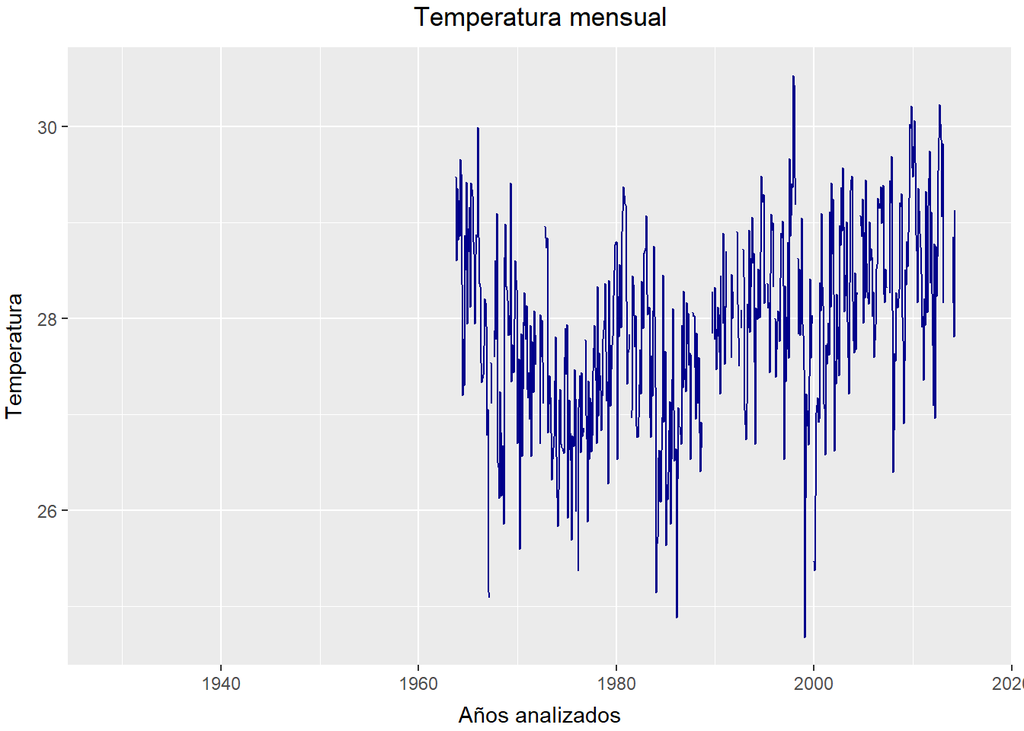

```r
ggplot(temp_mensual, aes(DATE, tmp)) +
  geom_line(color = "darkblue") +
  labs(x = "Años analizados", y = "Temperatura") +
  ggtitle("Temperatura mensual") +
  theme(
    plot.title = element_text(vjust = 2, hjust = 0.5),
    axis.title.x = element_text(vjust = -0.5),
    axis.title.y = element_text(vjust = 2.5)
  )
```

*A continuación tenemos una mejor vista de los valores obtenidos líneas arriba*

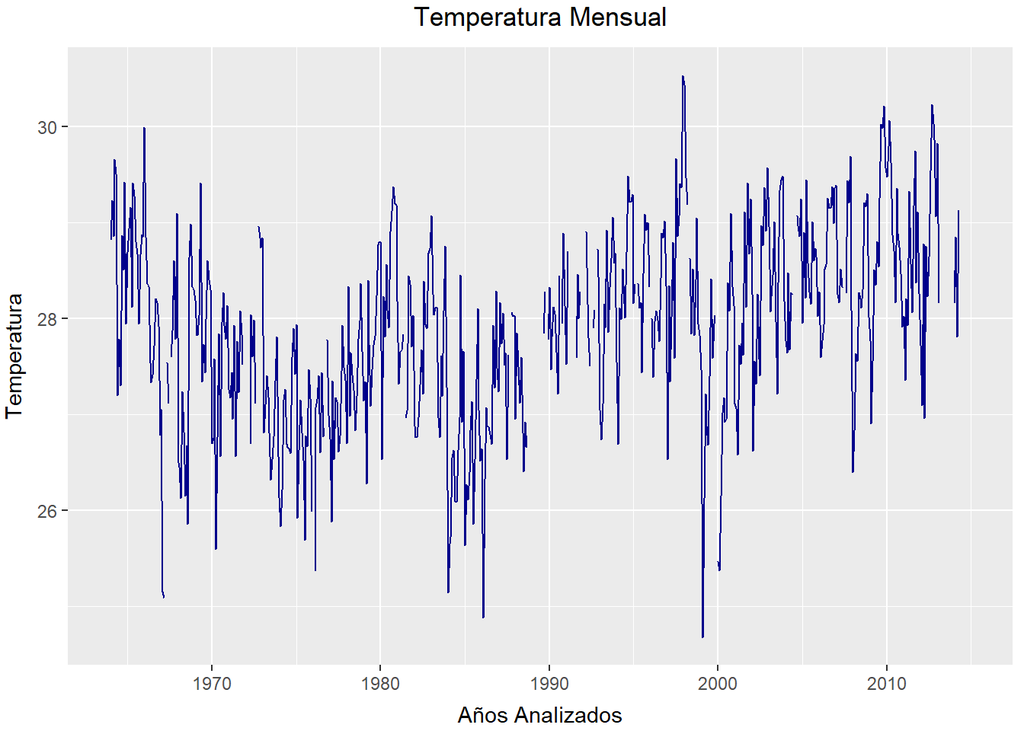

```r
ggplot(temp_mensual %>% filter(DATE >= "1964-01-01" & DATE < "2015-01-01"), aes(DATE, tmp)) +
  geom_line(color = "darkblue") +
  labs(x = "Años Analizados", y = "Temperatura") +
  ggtitle("Temperatura Mensual") +
  theme(
    plot.title = element_text(vjust = 2, hjust = 0.5),
    axis.title.x = element_text(vjust = -0.5),
    axis.title.y = element_text(vjust = 2.5)
  )
```

*Comentario*: La figura presenta muchos datos NA a partir del año 1928 hasta el año 1960 , donde se inicia a registrar la temperatura.